# Social Mobility: “Is your life really in your own hands?”

Calid Shorter

12/9/2018

### Introduction

- Is individual success determined by salary levels? How about overall life satisfaction? Such determination is subject to opinion; however, for the sake of analyzing the idea of life being fair, we will use income as a default detriment of success.
- The idea of success is the medium that we will use to explore social mobility. An individual’s ability to be socially mobile– by attaining higher social status– measures how fair life is. This idea, more precisely, is referred to as verticle mobility opposed to horizontal mobility and lateral mobility.
- No matter an individual’s socioeconomic location, the strength of fairness in the world is determined by the overall measure of everyone’s ability to move up the social economic ladder.

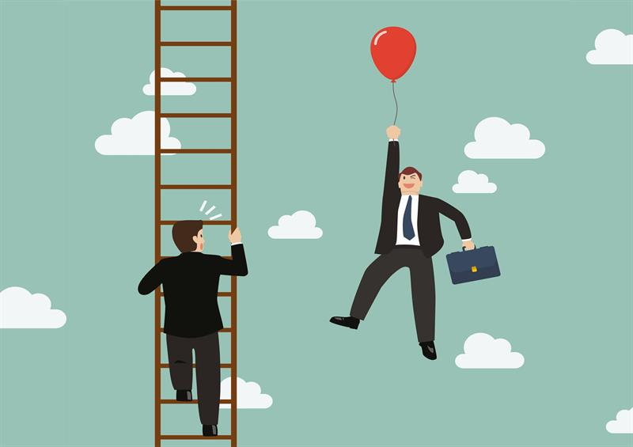

This picture depicts a representation of verticle mobility that suggest people’s process for reaching higher levels are different.

### Objective

- Analyze the most influential socioeconomic factors that are associated with success.
- Explore influential socioeconomic factors and compare across group differences to find intersectional trends.
- Determine if life is fair by measuring the strength of social mobility as it relates to specific socioeconomic factors.

### Methods

Used data from the Bureau of Labor Statistics, which is a part of The U.S Department of labor. “The U.S. Department of Labor is the principal federal agency responsible for measuring labor market activity, working conditions, and price changes in the economy.” (BLS.com)

- Downloaded variables from two data sets: **“NLSY 1979”** and **“NLSY79 Child and Young Adult”**
  - The NLSY 1979 data set provides a nationally representative sample of 12,000 adults who were between the ages of 14 and 22 years old when they were first surveyed in 1979. This cohort continues to be interviewed every two years.
  - The NLSY 1979 Child and Young Adult cohort is a second group of respondents who are the biological children of mother’s interviewed in the NLSY79 cohort.
  - The purpose of this survey design proves useful in tracking long term progress of America’s people.

#### Manipulating the Datasets

Filtering both data sets allows us to explore an intergenerational view of social mobility after subtracting mothers out of the NLSY79 data set. Hereby, linking mothers to children as it provides an easily identifiable link between mothers and biological childen.

1. create two subpopulations: mothers and the children of these mothers with associated variables
2. filter each data set according to variableS of intrest for visual representation

```r
#Filter mother data by race and replace all missing values in income columns with a special
#symbol to ignore such values when considering statistical summarization.
#(1=Hispanic, 2= Black, 3= nonwhite/nonhispanic)
hispanicMoms    <-filter(NLSY79m, Race== 1) %>% mutate_all(~ replace( ., .<0, NA))
blackMoms       <-filter(NLSY79m, Race== 2) %>% mutate_all(~ replace( ., .<0, NA))
white_OtherMoms <-filter(NLSY79m, Race== 3) %>% mutate_all(~ replace( ., .<0, NA))
```

```r
#Filter children data by race and replace all missing values in income columns with a special
#symbol to ignore such values when considering statistical summarization.
#(1=Hispanic, 2= Black, 3= nonwhite/nonhispanic)
hispanicChildren    <-filter(NLSCYA, raceChild== 1) %>% mutate_all(~ replace( ., .<0, NA))
blackChildren       <-filter(NLSCYA, raceChild== 2) %>% mutate_all(~ replace( ., .<0, NA))
white_OtherChildren <-filter(NLSCYA, raceChild== 3) %>% mutate_all(~ replace( ., .<0, NA))
```

### Results

##### Consumer Price Index (CPI)

Today, it is extrmely difficult to operate outside the confines of money, it seems like evrything cost which really stresses lower income families. Though, when the cost of livng increases, everyones purchasing power goes down– atleast in the short run. After six plus months to a couple of years, there are economic standards implemented to adjust for the rising cost of living. The question is who is affected most by inconsistencies and are they supported in times of need?

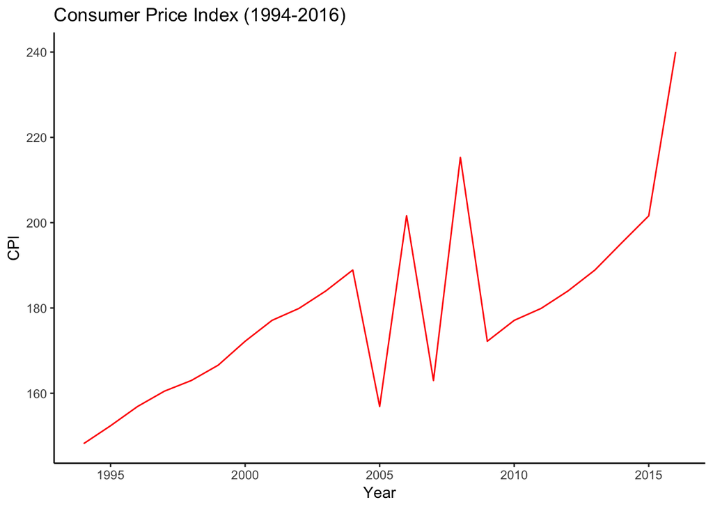

```r
#Graph average CPI over years 1994'- 2016'
ggplot(data= cpiTable) + geom_line(mapping = aes(x = Year, y = CPI), colour= "red")+
                         theme_classic()+
                         scale_y_continuous(breaks = seq(100, 300, by = 20))+
                         labs(title= paste("Consumer Price Index (1994-2016)")
                         )
```

- CPI is often referred to as the cost of living. The average person’s cost of living takes into account the following expenses:
  - Food and Beverages
  - Housing (rent of primary residence, fuel oil, befroom furniture)
  - Clothes (men’s shirts and sweaters, women’s dresses, jewelry)
  - Transportation (new vehicles, airline fares, gas, car insurance)
  - Medical Care (prescription drugs and medical supplies, physicians’ services, hospital services)
  - Recreation (TVs, toys, pets and pet services, sports equipment, admissions)
  - Education and Communication (college tuition, postage, telephone services, computer software and accessories)
  - Other Goods and Services (tobacco and smoking products, haircuts and other personal services, funeral expenses)
- Collective bargaining agreements although not always true

##### Analyzing the Data: Generation 1

United States law implemented policy throughout history that deprieves underprivledged groups from opportunities that could pottentially raise their socioeconomic location.

```r
# Use summary means to organize average income data for Black children sample, Hispanic
# children Sample, and the White/Other child serpent .
avgIncRace_Mothers <- tribble(
~year, ~hispanic, ~black, ~nonWhite_nonHispanic,
#------|--------|---------|---------------------
1994, 12588, 11253, 14609,
1998, 16952, 15016, 17801,
2000, 19839, 18528, 21408,
2004, 23395, 21256, 25387,
2008, 25848, 24596, 30307,
2010, 25863, 24452, 31105,
2012, 26888, 23122, 31925,
2014, 26685, 23442, 31533
)
```

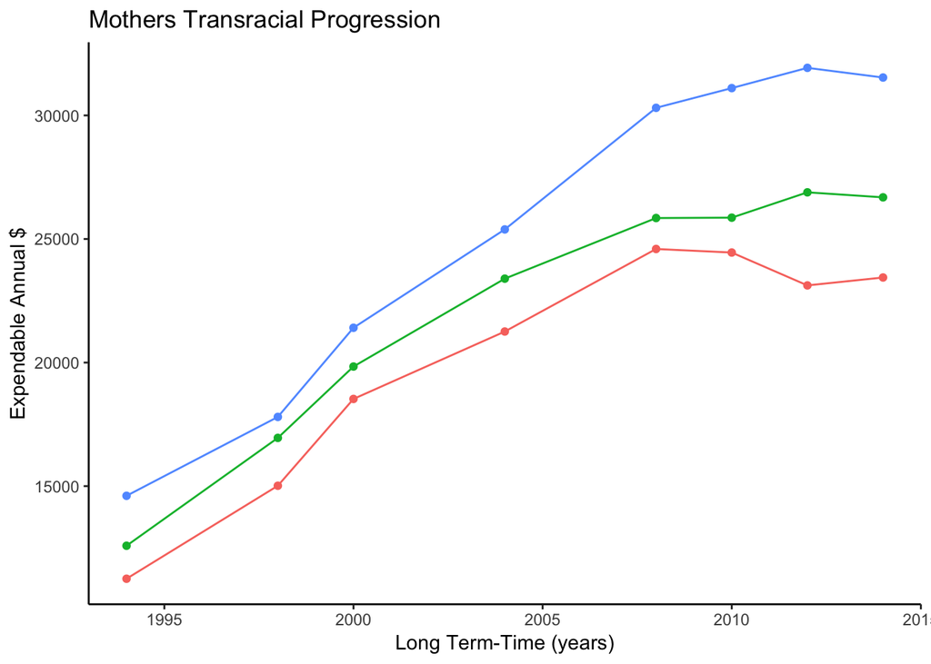

```r
#Long-term line graph ploting average expendables incomes for mothers across races.
ggplot(data= avgIncRace_Mothers)+geom_line(mapping = aes(x = year, y = hispanic, colour="green"))+
                          geom_line(mapping = aes(x= year, y= nonWhite_nonHispanic, colour="red"))+
                          geom_line(mapping = aes(x = year, y = black, colour="blue"))+
                          geom_point(mapping = aes(x= year, y= hispanic, colour= "green"))+
                          geom_point(mapping = aes(x=year, y= black, colour= "blue"))+
                          geom_point(mapping = aes(x= year, y= nonWhite_nonHispanic, colour="red"))+
                          theme_classic()+
                          theme(legend.position="none")+
                          labs(title= paste("Mothers Transracial Progression")
                                                 ,x = "Long Term-Time (years)"
                                                 ,y = "Expendable Annual $")
```

- 2004 - 2008: large amount of seperation
- During hard times, in relation to the corresponding CPI during the recession, white and other people experienced less detrimental effects than people of color.

##### Analyzing the data: Generation 2

Having data from both the mother cohorts and their biological children provides an opportunity to examine data across generations.

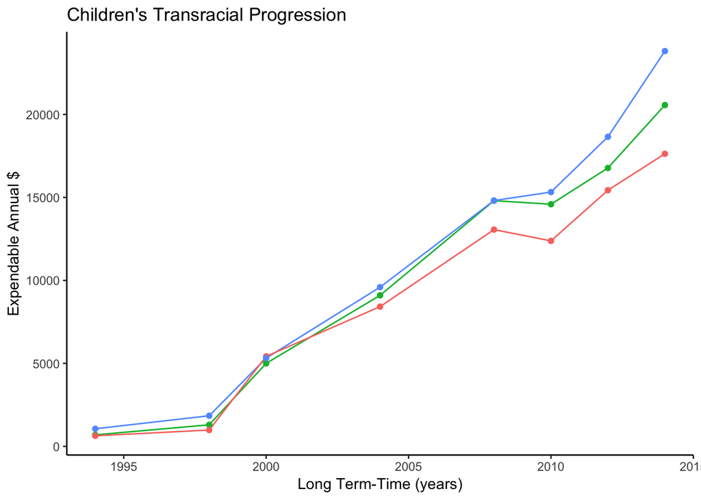

```r
# Long-term line graph of Childrens annual average expendable income compared by race.
ggplot(data= avgIncRace_Children)+geom_line(mapping = aes(x = year, y = hispanic, colour= "green"))+
                          geom_line(mapping = aes(x= year, y= nonWhite_nonHispanic, colour= "red"))+
                          geom_line(mapping = aes(x = year, y = black, colour = "blue"))+
                          geom_point(mapping = aes(x= year, y= hispanic, colour= "green"))+
                          geom_point(mapping = aes(x=year, y= black, colour = "blue"))+
                          geom_point(mapping = aes(x= year, y= nonWhite_nonHispanic, colour= "red"))+
                          theme_classic()+
                          theme(legend.position="none")+
                          labs(title= paste("Children's Transracial Progression")
                                                 ,x = "Long Term-Time (years)"
                                                 ,y = "Expendable Annual $")
```

- All children start off at similar points.
  - Need statistics on how many people where how old at which points in the graph
- 2nd generation inherets the same pattern the first generation

### Cross-sectional Themes

[figure not shown]

A cartoon style critic of the American Dream

- American Dream
- Race In America
- Intergenerational Mobility
- United States Economy

### Conclusion

Based on the data collected in this study, it can be concluded that vertical mobility is influenced by the socioeconomic location of individuals parents. Patterns in the data identify a pattern of children following the same trajectory, as it relates to income and socioeconomic class, as their parents. There is a clear disparity in these trajectories based on the race of the individuals. White and non-black/ non-latino people tend to have higher levels of expendable income opposed to Hispanics and Blacks. This disparity shows how racial demographics influence who is socially mobile. There are more variables to analyze before declaring whether this racial disparity within verticle mobility is fair or not.

Moreover, this disparity can be linked to several environmental factors such as education. Education is an influential socioeconomic factor that is often used to predict individual success. In an extended study of social mobility, we can use education attainment levels to explore if people across difference are recieving the same amount of pay and higher carrer level positions that should return a higher social class. Evenmore, it would be beneficial to examine these same variables with a particualr focus on one group, rather such group is determined by geolocial location, class, race or gender etc.

Research shows that it is very hard for people in the lowest and highest socioeconomic classes to move up or down as it relates to vertical mobility. More research can look further into a smaller range of groups to find interesting trends. Its difficult and bad practice to analyze data from such a wide data set without exploring on a more micro level first. After exploring on a micro level, data scientist can then collaborate and compare for valuable information.

### Acknowledgements

- Dr. Lucia Dale x Sewanee: The University of the South
- Bureau of Labor Statistics
- Consumer News and Business Channel (CNBC)